# Part I - Loan Data from Prosper

## by Adegboye Okikioluwa

## Introduction

> This data set contains 113,937 loans with 81 variables on each loan. The following variables were used in this analysis
> - CreditGrade The Credit rating that was assigned at the time the listing went live. Applicable for listings pre-2009 period and will only be populated for those listings.
> - Term The length of the loan expressed in months.
> - LoanStatus The current status of the loan: Cancelled, Chargedoff, Completed, Current, Defaulted, FinalPaymentInProgress, - PastDue. The PastDue status will be accompanied by a delinquency bucket.
> - BorrowerAPR The Borrower's Annual Percentage Rate (APR) for the loan.
> - BorrowerRate The Borrower's interest rate for this loan.
> - EstimatedLoss Estimated loss is the estimated principal loss on charge-offs. Applicable for loans originated after July 2009.
> - EstimatedReturn The estimated return assigned to the listing at the time it was created. Estimated return is the difference between the Estimated Effective Yield and the Estimated Loss Rate. Applicable for loans originated after July 2009.
> - ProsperRating (Alpha) The Prosper Rating assigned at the time the listing was created between AA - HR. Applicable for loans originated after July 2009.
> - ListingCategory The category of the listing that the borrower selected when posting their listing: 0 - Not Available, 1 - Debt Consolidation, 2 - Home Improvement, 3 - Business, 4 - Personal Loan, 5 - Student Use, 6 - Auto, 7- Other, 8 - Baby&Adoption, 9 - Boat, 10 - Cosmetic Procedure, 11 - Engagement Ring, 12 - Green Loans, 13 - Household Expenses, 14 - Large Purchases, 15 - Medical/Dental, 16 - Motorcycle, 17 - RV, 18 - Taxes, 19 - Vacation, 20 - Wedding Loans
> - BorrowerState The two letter abbreviation of the state of the address of the borrower at the time the Listing was created.
> - Occupation The Occupation selected by the Borrower at the time they created the listing.
> - EmploymentStatus The employment status of the borrower at the time they posted the listing.
> - IsBorrowerHomeowner A Borrower will be classified as a homowner if they have a mortgage on their credit profile or provide documentation confirming they are a homeowner.
> - AvailableBankcardCredit The total available credit via bank card at the time the credit profile was pulled.
> - DebtToIncomeRatio The debt to income ratio of the borrower at the time the credit profile was pulled. This value is Null if the debt to income ratio is not available. This value is capped at 10.01 (any debt to income ratio larger than 1000% will be returned as 1001%).
> - IncomeRange The income range of the borrower at the time the listing was created.
> - StatedMonthlyIncome The monthly income the borrower stated at the time the listing was created.
> - LoanKey Unique key for each loan. This is the same key that is used in the API.
> - LoanNumber Unique numeric value associated with the loan.
> - LoanOriginalAmount The origination amount of the loan.
> - LoanOriginationDate The date the loan was originated.
> - LoanOriginationQuarter The quarter in which the loan was originated.
> - MonthlyLoanPayment The scheduled monthly loan payment.

## Preliminary Wrangling

```python
# import all packages and set plots to be embedded inline
import numpy as np
import pandas as pd
import matplotlib.pyplot as plt
import seaborn as sb

%matplotlib inline
```

```python
df = pd.read_csv('prosperLoanData.csv')
```

```python
pd.set_option("display.max_columns", None)
df.head(15)
```

|  | ListingKey | ListingNumber | ListingCreationDate | CreditGrade | Term | LoanStatus | ClosedDate | BorrowerAPR | BorrowerRate | LenderYield | EstimatedEffectiveYield | EstimatedLoss | EstimatedReturn | ProsperRating (numeric) | ProsperRating (Alpha) | ProsperScore | ListingCategory (numeric) | BorrowerState | Occupation | EmploymentStatus | EmploymentStatusDuration | IsBorrowerHomeowner | CurrentlyInGroup | GroupKey | DateCreditPulled | CreditScoreRangeLower | CreditScoreRangeUpper | FirstRecordedCreditLine | CurrentCreditLines | … |
| --- | --- | --- | --- | --- | --- | --- | --- | --- | --- | --- | --- | --- | --- | --- | --- | --- | --- | --- | --- | --- | --- | --- | --- | --- | --- | --- | --- | --- | --- | --- |
| 0 | 1021339766868145413AB3B | 193129 | 2007-08-26 19:09:29.263000000 | C | 36 | Completed | 2009-08-14 00:00:00 | 0.16516 | 0.1580 | 0.1380 | NaN | NaN | NaN | NaN | NaN | NaN | 0 | CO | Other | Self-employed | 2.0 | True | True | NaN | 2007-08-26 18:41:46.780000000 | 640.0 | 659.0 | 2001-10-11 00:00:00 | 5.0 | … |
| 1 | 10273602499503308B223C1 | 1209647 | 2014-02-27 08:28:07.900000000 | NaN | 36 | Current | NaN | 0.12016 | 0.0920 | 0.0820 | 0.07960 | 0.0249 | 0.05470 | 6.0 | A | 7.0 | 2 | CO | Professional | Employed | 44.0 | False | False | NaN | 2014-02-27 08:28:14 | 680.0 | 699.0 | 1996-03-18 00:00:00 | 14.0 | … |
| 2 | 0EE9337825851032864889A | 81716 | 2007-01-05 15:00:47.090000000 | HR | 36 | Completed | 2009-12-17 00:00:00 | 0.28269 | 0.2750 | 0.2400 | NaN | NaN | NaN | NaN | NaN | NaN | 0 | GA | Other | Not available | NaN | False | True | 783C3371218786870A73D20 | 2007-01-02 14:09:10.060000000 | 480.0 | 499.0 | 2002-07-27 00:00:00 | NaN | … |
| 3 | 0EF5356002482715299901A | 658116 | 2012-10-22 11:02:35.010000000 | NaN | 36 | Current | NaN | 0.12528 | 0.0974 | 0.0874 | 0.08490 | 0.0249 | 0.06000 | 6.0 | A | 9.0 | 16 | GA | Skilled Labor | Employed | 113.0 | True | False | NaN | 2012-10-22 11:02:32 | 800.0 | 819.0 | 1983-02-28 00:00:00 | 5.0 | … |
| 4 | 0F023589499656230C5E3E2 | 909464 | 2013-09-14 18:38:39.097000000 | NaN | 36 | Current | NaN | 0.24614 | 0.2085 | 0.1985 | 0.18316 | 0.0925 | 0.09066 | 3.0 | D | 4.0 | 2 | MN | Executive | Employed | 44.0 | True | False | NaN | 2013-09-14 18:38:44 | 680.0 | 699.0 | 2004-02-20 00:00:00 | 19.0 | … |
| 5 | 0F05359734824199381F61D | 1074836 | 2013-12-14 08:26:37.093000000 | NaN | 60 | Current | NaN | 0.15425 | 0.1314 | 0.1214 | 0.11567 | 0.0449 | 0.07077 | 5.0 | B | 10.0 | 1 | NM | Professional | Employed | 82.0 | True | False | NaN | 2013-12-14 08:26:40 | 740.0 | 759.0 | 1973-03-01 00:00:00 | 21.0 | … |
| 6 | 0F0A3576754255009D63151 | 750899 | 2013-04-12 09:52:56.147000000 | NaN | 36 | Current | NaN | 0.31032 | 0.2712 | 0.2612 | 0.23820 | 0.1275 | 0.11070 | 2.0 | E | 2.0 | 1 | KS | Sales - Retail | Employed | 172.0 | False | False | NaN | 2013-04-12 09:52:53 | 680.0 | 699.0 | 2000-09-29 00:00:00 | 10.0 | … |
| 7 | 0F1035772717087366F9EA7 | 768193 | 2013-05-05 06:49:27.493000000 | NaN | 36 | Current | NaN | 0.23939 | 0.2019 | 0.1919 | 0.17830 | 0.0799 | 0.09840 | 4.0 | C | 4.0 | 2 | CA | Laborer | Employed | 103.0 | False | False | NaN | 2013-05-05 06:49:25 | 700.0 | 719.0 | 1999-02-25 00:00:00 | 6.0 | … |
| 8 | 0F043596202561788EA13D5 | 1023355 | 2013-12-02 10:43:39.117000000 | NaN | 36 | Current | NaN | 0.07620 | 0.0629 | 0.0529 | 0.05221 | 0.0099 | 0.04231 | 7.0 | AA | 9.0 | 7 | IL | Food Service | Employed | 269.0 | True | False | NaN | 2013-12-02 10:43:39 | 820.0 | 839.0 | 1993-04-01 00:00:00 | 17.0 | … |
| 9 | 0F043596202561788EA13D5 | 1023355 | 2013-12-02 10:43:39.117000000 | NaN | 36 | Current | NaN | 0.07620 | 0.0629 | 0.0529 | 0.05221 | 0.0099 | 0.04231 | 7.0 | AA | 11.0 | 7 | IL | Food Service | Employed | 269.0 | True | False | NaN | 2013-12-02 10:43:39 | 820.0 | 839.0 | 1993-04-01 00:00:00 | 17.0 | … |
| 10 | 0F123545674891886D9F106 | 587746 | 2012-05-10 07:04:01.577000000 | NaN | 60 | Current | NaN | 0.27462 | 0.2489 | 0.2389 | 0.23320 | 0.0890 | 0.14420 | 4.0 | C | 7.0 | 1 | MD | Fireman | Employed | 300.0 | False | False | NaN | 2012-04-22 08:38:09 | 640.0 | 659.0 | 1989-11-29 00:00:00 | 2.0 | … |
| 11 | 0F1734025150298088A5F2B | 213551 | 2007-10-09 20:28:33.640000000 | C | 36 | Completed | 2008-01-07 00:00:00 | 0.15033 | 0.1325 | 0.1225 | NaN | NaN | NaN | NaN | NaN | NaN | 0 | NaN | Waiter/Waitress | Full-time | 19.0 | False | False | NaN | 2007-10-08 13:13:44.363000000 | 640.0 | 659.0 | 2000-11-13 00:00:00 | 2.0 | … |
| 12 | 0F1A3597143888805163EF7 | 1081604 | 2013-12-15 20:01:10.757000000 | NaN | 36 | Past Due (1-15 days) | NaN | 0.17969 | 0.1435 | 0.1335 | 0.12640 | 0.0524 | 0.07400 | 5.0 | B | 4.0 | 1 | AL | Sales - Retail | Employed | 1.0 | False | False | NaN | 2013-12-15 20:01:13 | 680.0 | 699.0 | 1996-11-09 00:00:00 | 9.0 | … |
| 13 | 0F1C3583260311305D68F87 | 840820 | 2013-07-15 16:28:28.087000000 | NaN | 36 | Current | NaN | 0.13138 | 0.1034 | 0.0934 | 0.09050 | 0.0274 | 0.06310 | 6.0 | A | 8.0 | 1 | AZ | Construction | Employed | 98.0 | True | False | NaN | 2013-07-11 16:51:03 | 740.0 | 759.0 | 2007-03-20 00:00:00 | 9.0 | … |
| 14 | 0F353575943675863D1AFC0 | 757359 | 2013-04-19 11:17:41.700000000 | NaN | 60 | Current | NaN | 0.11695 | 0.0949 | 0.0849 | 0.08270 | 0.0224 | 0.06030 | 6.0 | A | 8.0 | 1 | VA | Computer Programmer | Employed | 35.0 | False | False | NaN | 2013-04-19 11:17:38 | 740.0 | 759.0 | 1992-07-06 00:00:00 | 25.0 | … |

```python
df.shape
```

```
(113937, 81)
```

## Data Cleaning

- Duplicates
- Unnecessary columns
- Listing Category column recorded in numbers

### Define

Remove duplicate rows using pandas drop_duplicate function and unnecessary columns

### Code

```python
#dropping duplicate rows
df_new = df.drop_duplicates(subset = 'LoanNumber')
```

```python
#dropping unnecessary columns
loandata = df_new[['LoanNumber', 'LoanOriginationDate', 'LoanOriginationQuarter', 'LoanOriginalAmount',
                   'MonthlyLoanPayment', 'EstimatedLoss', 'EstimatedReturn',
                   'CreditGrade', 'Term', 'LoanStatus', 'ProsperRating (Alpha)',
                   'ListingCategory (numeric)', 'BorrowerState', 'Occupation', 'EmploymentStatus',
                  'IsBorrowerHomeowner', 'IncomeRange', 'StatedMonthlyIncome', 'DebtToIncomeRatio',
                  'BorrowerRate', 'BorrowerAPR', 'AvailableBankcardCredit']]
```

### Test

```python
loandata.shape
```

```
(113066, 22)
```

```python
df_duplicate = df[df.LoanNumber.duplicated(keep=False) == True].sort_values('LoanNumber', ascending=True)
```

### Define

Replace Numeric category in listing category with what they truly represent

### Code

```python
category = {0 : 'Not Available', 1 : 'Debt Consolidation', 2 : 'Home Improvement', 3 : 'Business', 4 : 'Personal Loan',
5 : 'Student Use', 6 : 'Auto', 7 : 'Other', 8 : 'Baby&Adoption', 9 : 'Boat', 10 : 'Cosmetic Procedure',
11 : 'Engagement Ring', 12 : 'Green Loans', 13 : 'Household Expenses', 14 : 'Large Purchases', 15 : 'Medical/Dental',
16 : 'Motorcycle', 17 : 'RV', 18 : 'Taxes', 19 : 'Vacation', 20 : 'Wedding Loans'}

loandata['ListingCategory (numeric)']=loandata['ListingCategory (numeric)'].map(category)
```

```python
loandata.rename(columns={'ListingCategory (numeric)': 'ListingCategory'}, inplace=True)
```

### Test

```python
loandata['ListingCategory']
```

```
0              Not Available
1           Home Improvement
2              Not Available
3                 Motorcycle
4           Home Improvement
5         Debt Consolidation
6         Debt Consolidation
7           Home Improvement
8                      Other
10        Debt Consolidation
11             Not Available
12        Debt Consolidation
13        Debt Consolidation
14        Debt Consolidation
15        Household Expenses
```

[output cut: 47 more lines]

```python
loandata.shape
```

```
(113066, 22)
```

```python
loandata.info()
```

```
<class 'pandas.core.frame.DataFrame'>
Int64Index: 113066 entries, 0 to 113936
Data columns (total 22 columns):
LoanNumber                 113066 non-null int64
LoanOriginationDate        113066 non-null object
LoanOriginationQuarter     113066 non-null object
LoanOriginalAmount         113066 non-null int64
MonthlyLoanPayment         113066 non-null float64
EstimatedLoss              83982 non-null float64
EstimatedReturn            83982 non-null float64
CreditGrade                28953 non-null object
Term                       113066 non-null int64
LoanStatus                 113066 non-null object
ProsperRating (Alpha)      83982 non-null object
ListingCategory            113066 non-null object
BorrowerState              107551 non-null object
Occupation                 109537 non-null object
EmploymentStatus           110811 non-null object
IsBorrowerHomeowner        113066 non-null bool
IncomeRange                113066 non-null object
StatedMonthlyIncome        113066 non-null float64
DebtToIncomeRatio          104594 non-null float64
BorrowerRate               113066 non-null float64
BorrowerAPR                113041 non-null float64
AvailableBankcardCredit    105522 non-null float64
dtypes: bool(1), float64(8), int64(3), object(10)
memory usage: 19.1+ MB
```

```python
loandata.head()
```

|  | LoanNumber | LoanOriginationDate | LoanOriginationQuarter | LoanOriginalAmount | MonthlyLoanPayment | EstimatedLoss | EstimatedReturn | CreditGrade | Term | LoanStatus | ProsperRating (Alpha) | ListingCategory | BorrowerState | Occupation | EmploymentStatus | IsBorrowerHomeowner | IncomeRange | StatedMonthlyIncome | DebtToIncomeRatio | BorrowerRate | BorrowerAPR | AvailableBankcardCredit |
| --- | --- | --- | --- | --- | --- | --- | --- | --- | --- | --- | --- | --- | --- | --- | --- | --- | --- | --- | --- | --- | --- | --- |
| 0 | 19141 | 2007-09-12 00:00:00 | Q3 2007 | 9425 | 330.43 | NaN | NaN | C | 36 | Completed | NaN | Not Available | CO | Other | Self-employed | True | $25,000-49,999 | 3083.333333 | 0.17 | 0.1580 | 0.16516 | 1500.0 |
| 1 | 134815 | 2014-03-03 00:00:00 | Q1 2014 | 10000 | 318.93 | 0.0249 | 0.05470 | NaN | 36 | Current | A | Home Improvement | CO | Professional | Employed | False | $50,000-74,999 | 6125.000000 | 0.18 | 0.0920 | 0.12016 | 10266.0 |
| 2 | 6466 | 2007-01-17 00:00:00 | Q1 2007 | 3001 | 123.32 | NaN | NaN | HR | 36 | Completed | NaN | Not Available | GA | Other | Not available | False | Not displayed | 2083.333333 | 0.06 | 0.2750 | 0.28269 | NaN |
| 3 | 77296 | 2012-11-01 00:00:00 | Q4 2012 | 10000 | 321.45 | 0.0249 | 0.06000 | NaN | 36 | Current | A | Motorcycle | GA | Skilled Labor | Employed | True | $25,000-49,999 | 2875.000000 | 0.15 | 0.0974 | 0.12528 | 30754.0 |
| 4 | 102670 | 2013-09-20 00:00:00 | Q3 2013 | 15000 | 563.97 | 0.0925 | 0.09066 | NaN | 36 | Current | D | Home Improvement | MN | Executive | Employed | True | $100,000+ | 9583.333333 | 0.26 | 0.2085 | 0.24614 | 695.0 |

### What is/are the main feature(s) of interest in your dataset?

> I am intrested in knowing what factors offers the best interest loans and what factors lead to the most successful loans

### What features in the dataset do you think will help support your investigation into your feature(s) of interest?

> I expect that the income, debt to income ratio, loan term would have great effect on interest rates and successful loans. I also think that past loan transactions such as credit Grade and available bank credit will have some effect on the loans interest rate and successful loans

## Univariate Exploration

## BorrowerAPR

```python
finite_APR = loandata[np.isfinite(loandata['BorrowerAPR'])]
```

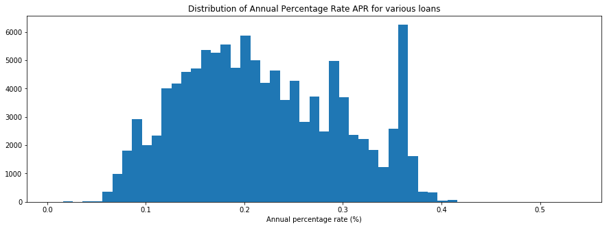

```python
plt.figure(figsize=(15,5))
bins = np.arange(0.006, 0.53+0.01, 0.01)
plt.hist(data=finite_APR, x='BorrowerAPR', bins=bins);
plt.title('Distribution of Annual Percentage Rate APR for various loans')
plt.xlabel('Annual percentage rate (%)');
```

The Histogram above is showing that most loans had an Annual Percentage Rate between 18% - 20% and 36%

## Monthly Income

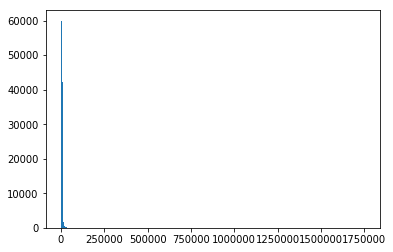

```python
bins = np.arange(loandata.StatedMonthlyIncome.min(), loandata.StatedMonthlyIncome.max()+5000, 5000)

plt.hist(data=loandata, x='StatedMonthlyIncome', bins=bins);
#plt.xscale('log')
#plt.yscale('log')
```

```python
loandata.drop(loandata.loc[loandata['StatedMonthlyIncome'] > 1750000].index, inplace=True)
```

```python
loandata.shape
```

```
(113065, 22)
```

```python
#removing outlier
smi = loandata.loc[loandata.StatedMonthlyIncome < 600000]
```

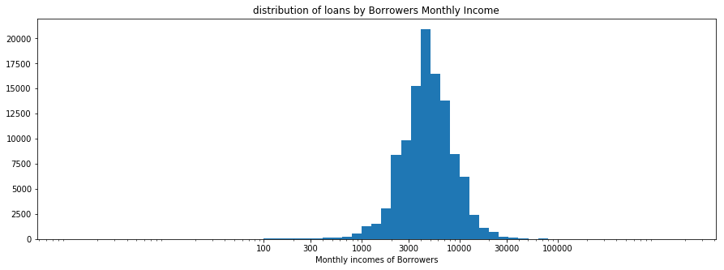

```python
plt.figure(figsize=(15,5))

bins = 10**np.arange(0, 6.3+0.1, 0.1)
plt.hist(data=smi, x='StatedMonthlyIncome', bins=bins)
plt.xscale('log')
bin_x = [100, 300, 1000, 3000, 10000, 30000, 100000]
bin_xnames = ["{}".format(i) for i in bin_x]
plt.xticks(bin_x, bin_xnames);

plt.title('distribution of loans by Borrowers Monthly Income')
plt.xlabel('Monthly incomes of Borrowers');
```

The Histogram is rightly skewed. We can see that there seem to be an outlier in the data from the first histogram. Using a log scale we can see a unimodal histogram with most borrowers monthly income falling between 3000 to 6000, although there is a longer tail to the left showing that a large number of borrowers monthly income falls between 100 - 6000

## Loan Original Amount

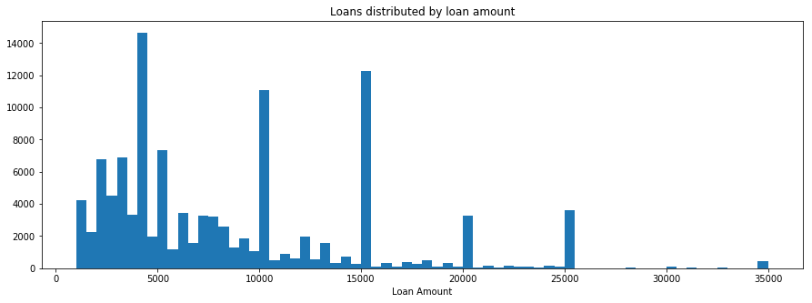

```python
plt.figure(figsize=(15,5))
bins = np.arange(loandata.LoanOriginalAmount.min(), loandata.LoanOriginalAmount.max()+500, 500)
plt.hist(data=loandata, x='LoanOriginalAmount', bins=bins)
plt.title('Loans distributed by loan amount')
plt.xlabel('Loan Amount');
```

The Histogram above has several sharp peaks due to most loans being requested to a rounded figure such as 10000, 15000, 20000, 25000. The amount of loans requested the most are between 1000 to 10000, while loans >20000 are less frequently requested

## Monthly Loan Payment

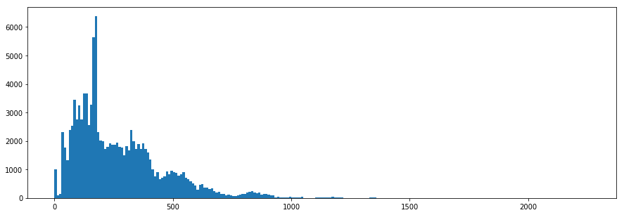

```python
plt.figure(figsize=(15,5))
bins = np.arange(loandata.MonthlyLoanPayment.min(), loandata.MonthlyLoanPayment.max()+10, 10)
plt.hist(data=loandata, x='MonthlyLoanPayment', bins=bins);
# bin_x = np.arange(0,2000, 50)
# bin_xnames = ['{}'.format(v) for v in bin_x]
# plt.xticks(bin_x, bin_xnames);
```

## Available Bank Credit

```python
finite_credit = loandata[np.isfinite(loandata['AvailableBankcardCredit'])]
```

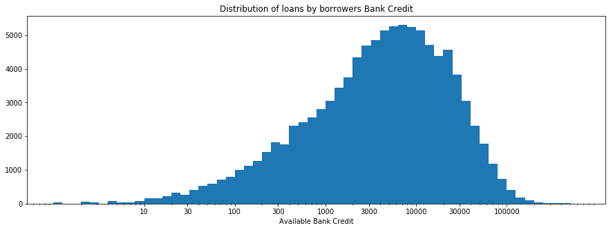

```python
plt.figure(figsize=(15,5))
bins = 10**np.arange(0.00, 5.8+0.1, 0.1)
plt.hist(data=finite_credit, x='AvailableBankcardCredit', bins=bins)
plt.xscale('log')

bin_x = [10, 30, 100, 300, 1000, 3000, 10000, 30000, 100000]
bin_xnames = ["{}".format(i) for i in bin_x]
plt.xticks(bin_x, bin_xnames);

plt.title('Distribution of loans by borrowers Bank Credit')
plt.xlabel('Available Bank Credit');
```

The Histogram is left skewed and peaks at 3000 to 8000, showimg that most borrowers have their bank credits between 0 - 8000

```python
#creating function for Splitting column names for titles
def splitstring(string):
    return ''.join([x if x.islower() else f" {x}" for x in string])
```

```python
#Creating function for creating plots
def chart(df, xvar, xy='x', figsize=(14,6), color=0, order=None):
    plt.figure(figsize=figsize)
    keys={xy:xvar, 'color':sb.color_palette()[color], 'order':order}
    sb.countplot(data=df, **keys)

    if xvar == 'newStatus':
        xvar = 'Loan Status'
    else:
        xvar = splitstring(xvar).replace("_"," ")

    plt.title(f"Distribution of {xvar}".title(), fontsize=14, weight="bold")
```

```python
#creating a function for annotations on chart
def annote(df, xvar, value_type=None):

    bs_type = df[xvar].value_counts()
    if value_type == 'percent':
        for i in range(bs_type.shape[0]):
            counts = bs_type[i]
            pct_string = '{:0.1f}%'.format(100*counts/loandata.shape[0])
            plt.text(counts+1, i, pct_string, va='center')
    else:
        for i in range(bs_type.shape[0]):
            counts = bs_type[i]
            pct_string = '{:0.1f}%'.format(counts)
            plt.text(counts+1, i, pct_string, va='center')
```

## Loan Status

```python
#combining all past due groups into one
loandata['newStatus'] = loandata.LoanStatus.apply(lambda x: x.replace(x, 'Past Due') if x[0:8] == 'Past Due' else x)
```

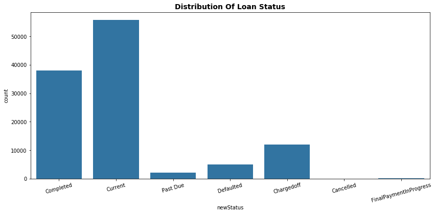

```python
chart(loandata, 'newStatus')

plt.xticks(rotation=15);
```

The chart Above shows that most loans are complete or are currently being carried out with no due payment

## Borrower State

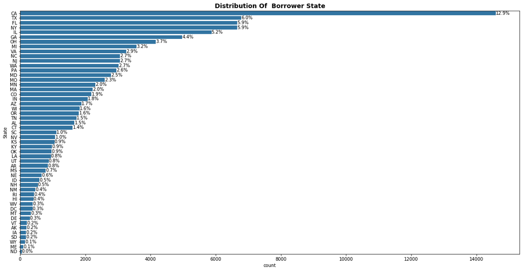

```python
chart(loandata, 'BorrowerState', xy='y', order=loandata.BorrowerState.value_counts().index, figsize=(20,10))
plt.ylabel('State')

annote(loandata, 'BorrowerState', value_type='percent')
```

The state with the most loans in the United states is Carlifornia, followed by Texas, Florida, New York. The state with the least loans are Wyoming, Maine, and North Dakota

## Listing Category

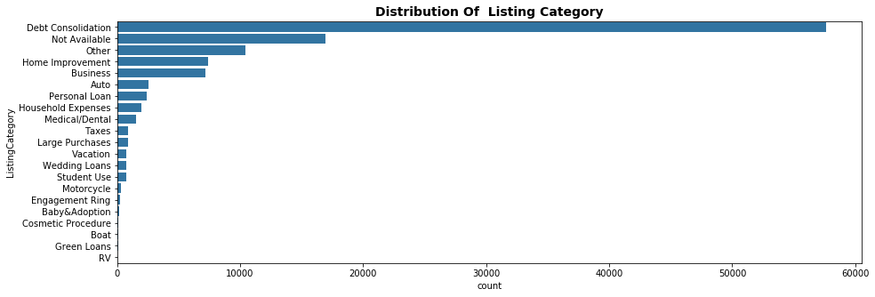

```python
chart(loandata, 'ListingCategory', xy='y', figsize=(15,5), order=loandata.ListingCategory.value_counts().index);
```

## Credit Grade

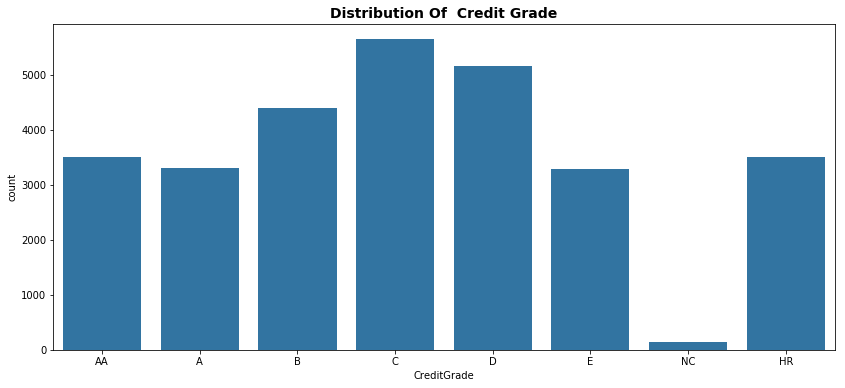

```python
chart(loandata, 'CreditGrade', order=['AA','A','B','C','D','E','NC','HR']);
```

Most Credit Grade fall between B to D

## Prosper Ratings

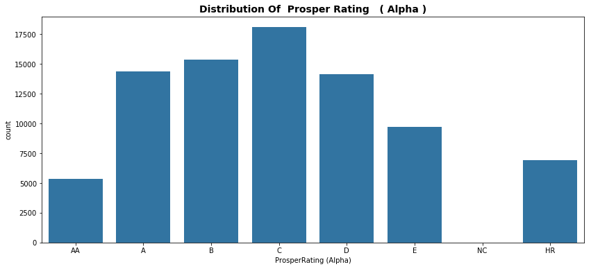

```python
chart(loandata, 'ProsperRating (Alpha)', order=['AA','A','B','C','D','E','NC','HR']);
```

The distribution Prosper loans company ratings on several loans is almost thesame with the credit grade rating with most ratings being between B and D. There are also more A ratings with less AA ratings.

## Occupation

```python
#Getting the top 10 occupations
g = loandata.loc[loandata.Occupation != 'Other']
h = g.Occupation.value_counts()[0:10]
```

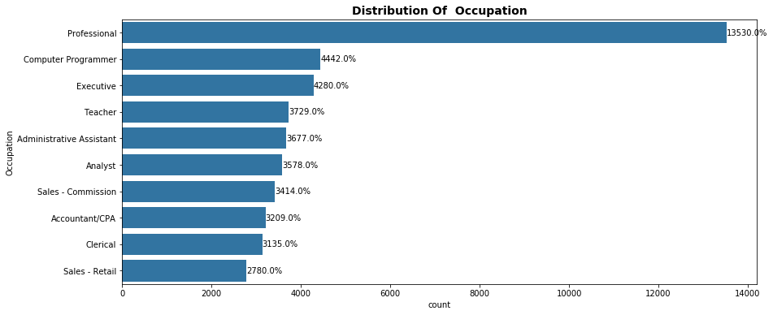

```python
data=loandata.query('Occupation in @h.index').copy()

chart(data, 'Occupation', xy='y', order=h.index)

annote(data, 'Occupation')
```

A high number of loans were taken by professionals, followed by computer programmers, executives then Teachers

## Employment Status

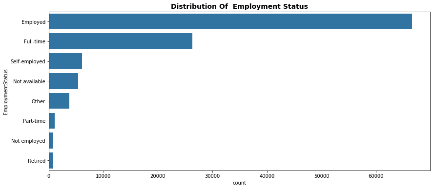

```python
chart(loandata, 'EmploymentStatus', xy='y', order=loandata.EmploymentStatus.value_counts().index);
```

Most Borrowers are Employed. The chart below shows this as the high end of the bars are by employed people while the low end of the bar chart are by people with little or no employemnt including retirees

## Loans by Year

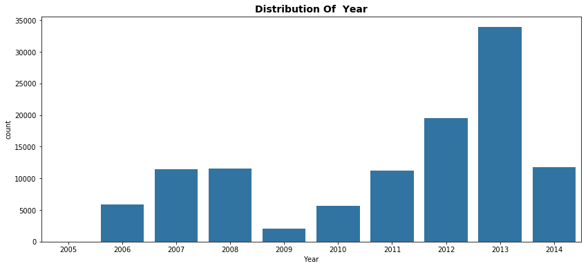

```python
loandata['Year'] = loandata.LoanOriginationQuarter.apply(lambda x: x[-4:])

chart(loandata, 'Year');
```

The chart clearly shows a steady rise between 2009 and 2013, with the most loan being requested at 2013 and a significant reduction by 2014

## Home Owner

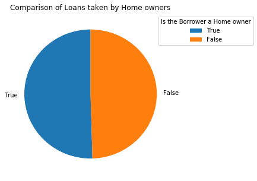

```python
plt.figure(figsize=(5,5))
g = loandata.IsBorrowerHomeowner.value_counts()
plt.title('Comparison of Loans taken by Home owners')
plt.pie(g, labels=g.index, startangle=90)
plt.legend(title='Is the Borrower a Home owner', bbox_to_anchor=(0.5, 0.5, 1, 0.5));
```

The pie chart shows that there is a 50-50distribution between borrowers who are home owners and those who are not

### Of the features you investigated, were there any unusual distributions? Did you perform any operations on the data to tidy, adjust, or change the form of the data? If so, why did you do this?

> The AvailableBankcardCredit and StatedMonthlyIncome column showed an unsual distribution, so we changes the scales of their axis to a log scale and the StatedMonthlyIncome column had some outliers which was removed before doing an analysis on the column

## Bivariate Exploration

## What are the Relationships between the variables in the data?

```python
I_arr = ['Not displayed', 'Not employed', '$0', '$1-24,999',
         '$25,000-49,999', '$50,000-74,999', '$75,000-99,999', '$100,000+']
arr = ['AA','A','B','C','D','E','NC','HR']
color = sb.color_palette()[0]
```

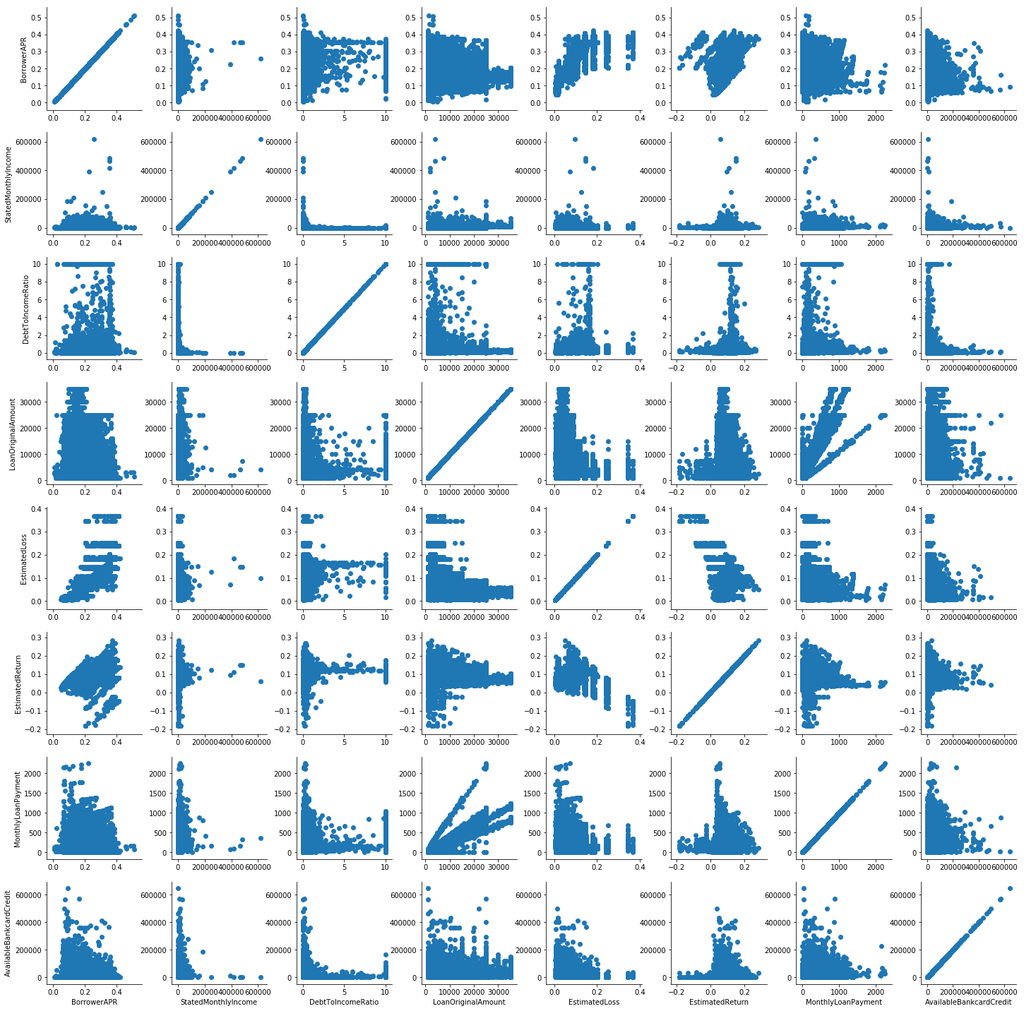

```python
new_vars = ['BorrowerAPR', 'StatedMonthlyIncome', 'DebtToIncomeRatio', 'LoanOriginalAmount',
           'EstimatedLoss', 'EstimatedReturn', 'MonthlyLoanPayment', 'AvailableBankcardCredit']

g = sb.PairGrid(data = loandata, vars = new_vars)
g.map(plt.scatter);
```

An increase in loan amount leads to a decrease in APR, while a decrease in loan amount leads to an increase in APR. The APR decreases with higher rating. Although most of the loan data are low, the loan amount increases with higher prosper ratings.  
The Higher the loan amount, Available bank credit the higher the estimated return and lower the estimated loss  
People with low debt income ratio tend to have a higher loan amount

## Loan Status vs BorrowerAPR

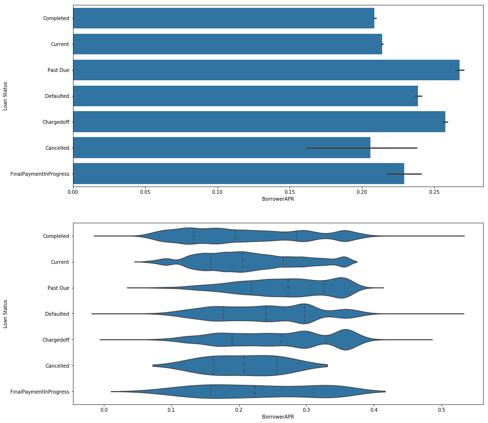

```python
fig, ax = plt.subplots(nrows=2, figsize=(15,15))
sb.barplot(data=loandata, x='BorrowerAPR', y='newStatus', ax=ax[0], color=color)
ax[0].set_ylabel('Loan Status')
sb.violinplot(data=loandata, x='BorrowerAPR', y='newStatus', inner='quartile', ax=ax[1], color=color)
ax[1].set_ylabel('Loan Status');
```

From the barplot below we can see that the mean APR was higher for loans that were Past Due, Defualted, and ChargedOff.

## Income Range vs Prosper Rating

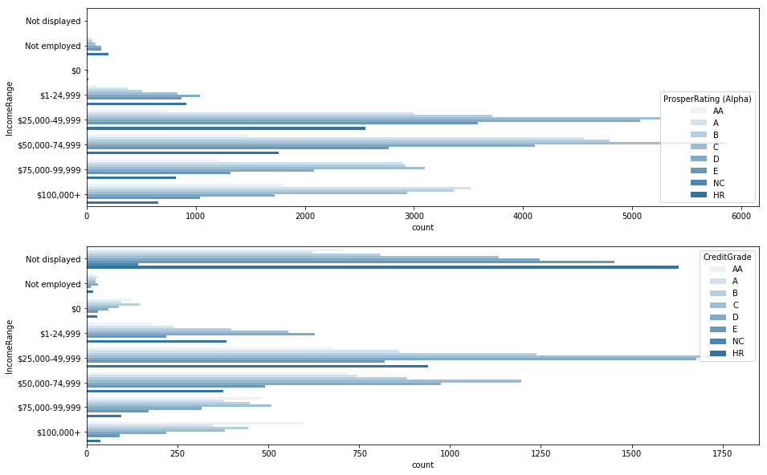

```python
fig, ax = plt.subplots(nrows=2, figsize=(15,10))
sb.countplot(data=loandata, y='IncomeRange', order=I_arr, hue='ProsperRating (Alpha)', hue_order=arr, color=color, ax=ax[0])
sb.countplot(data=loandata, y='IncomeRange', order=I_arr, hue='CreditGrade', hue_order=arr, color=color, ax=ax[1]);
```

The plot shows that low icomes have bad prosper ratings while average incomes between 25k - 75k have prosper ratings between C and D and high income earners recieve high ratings

# BorrowerAPR vs CreditGrade and ProsperRating

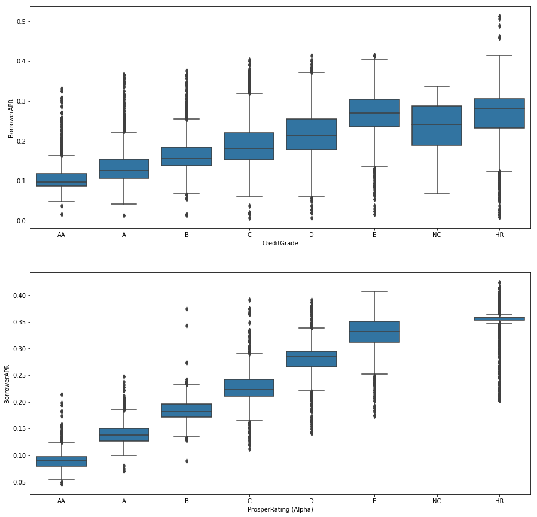

```python
arr = ['AA','A','B','C','D','E','NC','HR']

fig, ax = plt.subplots(nrows=2, figsize=(15,15))
sb.boxplot(data=loandata, y='BorrowerAPR', x='CreditGrade', order=arr, ax=ax[0], color=color)
sb.boxplot(data=loandata, y='BorrowerAPR', x='ProsperRating (Alpha)', order=arr, ax=ax[1], color=color);
```

Better Credit Grades and Prosper ratings results in lower APR

## Loan Status and Debt to income ratio

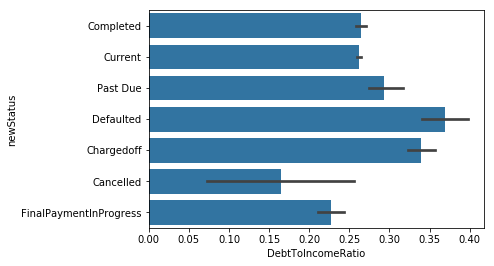

```python
sb.barplot(data=loandata, y='newStatus', x='DebtToIncomeRatio', color=color);
```

Borrowers who were Past Due, Defualted and Charged Off had a higher Debt to income Ratio

## Available Bank credit vs Prosper rating

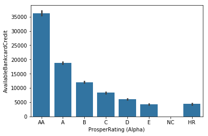

```python
sb.barplot(data=loandata, y='AvailableBankcardCredit', x='ProsperRating (Alpha)', order=arr, color=color);
```

High bank credits are given higher ratings

## Loan Amount vs Prosper rating

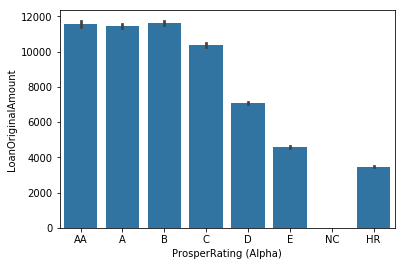

```python
sb.barplot(data=loandata, y='LoanOriginalAmount', x='ProsperRating (Alpha)', order=arr, color=color);
```

Borrowers with high ratings tend to borrow more amount of money

## Available Bank card credit vs Debt to income ratio

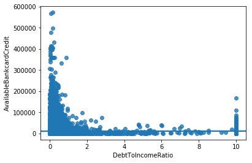

```python
sb.regplot(data=loandata, y='AvailableBankcardCredit', x='DebtToIncomeRatio');
```

The borrowers with low amounts in there credit cards are likely to have a higher debt to income ratio and vice versa

### Talk about some of the relationships you observed in this part of the investigation. How did the feature(s) of interest vary with other features in the dataset?

> Loans that were Past Due, Charged Off or Defualted had higher average Annual Percentage Rates than other loan status.
> - The BorrowerAPR is also affected by the Loan amount such that the higher the loan amount the lesser the Annual Percentage Rates especially loan amounts >25K. This may have been done on purpose so as to make borrowers request for more money becuase a larger loan amount will yield a larger estimated return between 0 to 0.3, while a smaller loan amount could get an estimated return below 0 or a larger estimated loss
> - Borrowers with low rating or high risk for both prosper ratings and credit grade have high Annual percentage rate than Borrowers with better ratings such as AA, A, and B.
> - Higher average Debt to income ratio led to Loanstatus that were Past Due, ChargedOff, or Defualted ### Did you observe any interesting relationships between the other features (not the main feature(s) of interest)?
> - Prosper Loans Rating depends on a Borrowers Monthly income and their Available bank card credit as borrowers with higher income or bank credit recieve better ratings.

## Multivariate Exploration

## Loan Amount vs BorrowerAPR and Prosper Rating

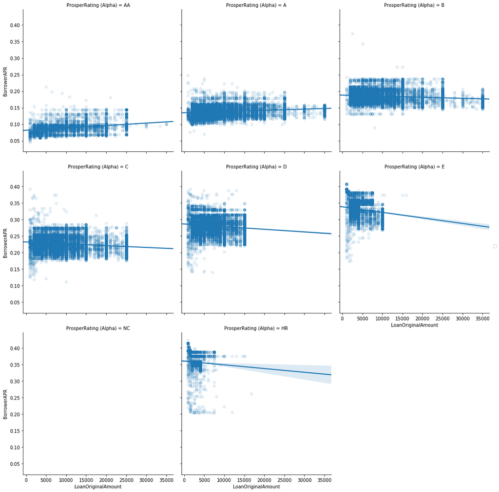

```python
g = sb.FacetGrid(data = loandata, col = 'ProsperRating (Alpha)', col_order=arr, col_wrap=3, size = 5)
g.map(sb.regplot, 'LoanOriginalAmount', 'BorrowerAPR', scatter_kws={'alpha':1/10})
g.add_legend();
```

The APR decreases with higher rating. Although most of the loan data are low, the loan amount increases with higher prosper ratings.

With better ratings from AA to A, the higher the Loan amount the higher the APR, while from B to HR ratings, the higher the loan amount the lower the APR

## BorrowerAPR vs Prosper Ratings and Term

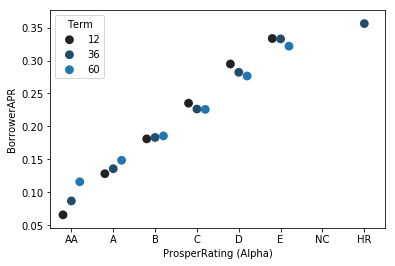

```python
sb.pointplot(data=loandata, x='ProsperRating (Alpha)', y='BorrowerAPR', dodge=0.4, hue='Term', linestyles='', order=arr, color=color);
```

The BorrowerAPR increases from 12 to 60 for prosper ratings from AA - B, while BorrowerAPR decreases from 12 to 60 for prosper ratings of C - HR

## Prosper Ratings vs Debt income ratio and Loan status

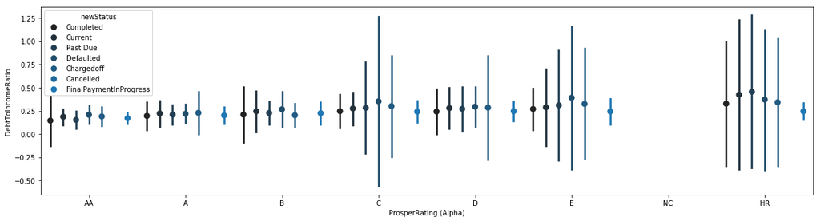

```python
plt.figure(figsize=(20,5))
sb.pointplot(data=loandata, x='ProsperRating (Alpha)', y='DebtToIncomeRatio', order=arr, dodge=0.8, hue='newStatus', linestyles='', color=color, ci='sd');
```

The chart above shows that low ratings were given to borrowers with high debt income ratio, and borrowers with higher debt income ratio had Past Due, Defualted, Charged Off loan status

### Talk about some of the relationships you observed in this part of the investigation. Were there features that strengthened each other in terms of looking at your feature(s) of interest?

> Borrowers with a high debt income ratio will have a higher annual rate on his/her loan, this might likely result in not being able to pay off the loan  
> Since people with better ratings tend to borrow more, increasing the APR will prevent them from borrowing even more, and decreasing the APR will people with low ratings to borrow more  
> A borrower having a high rating and short term will pay less charges on a loan. If a borrower has a low rating, it will be better to have a longer term to pay less charges on loan, althogh it can not be as low as the later.

```python
#storing master dataset
loandata.to_csv('loandata.csv', index=False)
```